# Parameter Estimation to Predict Lizard Weight

Conner Smith

1/31/2022

```r
knitr::opts_chunk$set(echo = TRUE, message = FALSE, warning = FALSE)

library(tidyverse)
library(here)
library(broom)
library(modelr)
library(cowplot)
library(kableExtra)
library(janitor)
```

## **Overview**

This analysis uses non linear least squares to estimate parameters of a snout length to weight model for lizard populations in New Mexico. It first estimates a model based on the entire data set including both male and female lizards across 13 species. The analysis then estimates a model specific to the Western Whiptail lizard (*Cnemidophorus tigrisatus*) and compares the predictive accuracy of the species-specific model to the general model.

```r
lizards <- read_csv(here("data", "lizard.csv")) %>%
  mutate(sex = case_when(sex == 'F' ~ 'Female',
                         sex == 'M' ~ 'Male'))
```

## **General Model - Parameter Selection**

We know from the data that we need to fit a model where:

$$\begin{equation}
W=a(SVL)^b
\end{equation}$$

In this model, W is weight and SVL is the snout-to-vent length. We need to estimate the parameters a and b which can be derived from the a regression applied to the data.

##### **Table 1:** *This tables shows the estimated parameters of the NLS model. Each had a p value below 0.001.*

```r
# Present the model in a table

tidy_nls <- tidy(lizards_nls)

tidy_nls$p.value <- ifelse(tidy_nls$p.value < .001, paste("< .001"))

tidy_nls %>%
  select(-statistic) %>%
  kable(col.names = c("Parameter", "Estimate",
                      "Standard Error", "P Value"), digits = 4) %>%
  kable_styling(bootstrap_options = "striped",
                position = "left", full_width = FALSE)
```

| Parameter | Estimate | Standard Error | P Value |
| --- | --- | --- | --- |
| a | 0.0003 | 0.000 | < .001 |
| b | 2.4532 | 0.027 | < .001 |

The parameter estimates were used to provide initial guesses for the model, $W=a(SVL)^b$. From the calculations here, we see that $a$ = 3.4^{-4} and $b$ = 2.45.

#### **Figure 1: Predicted Versus Actual Lizard Weights**

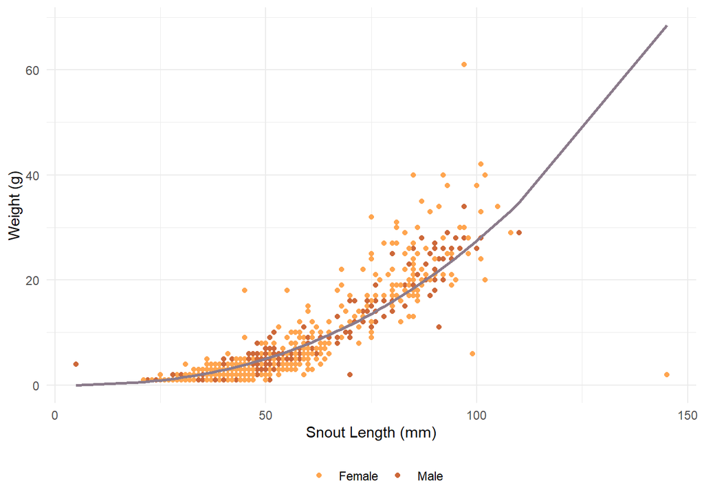

```r
# Use the nls to generate predictions from the data

general_model_predict <- predict(lizards_nls)

# Bind  predictions to the main data frame

lizards_complete <- data.frame(lizards, general_model_predict)

# Plot the predictions colored by sex:
ggplot(data = lizards_complete,
       aes(x = SV_length, y = general_model_predict)) +
  geom_point(aes(x = SV_length, y = weight, color = sex),
             size = 1.5) +
  scale_color_manual(values = c('tan1', 'sienna3')) +
  geom_line(color = 'thistle4', size = 1) +
  theme_minimal() +
  theme(legend.title = element_blank(),
        legend.position = "bottom") +
  labs(x = "Snout Length (mm)",
       y = "Weight (g)")
```

##### **Figure 1:** *This graph shows the actual weight of lizards separated by sex and a fitted non-linear least squares model (the purple line) that predicts wight from snout to vent length.*

This graph shows that the fitted model predicts lizard weight from snout to vent length relatively closely. This shows that the initial parameter estimation strategy resulted in acceptable guesses to base this general model. The following section looks more closely at species-specific models.

## **Species-Specific Model Comparison**

#### **Figure 2: Model Comparison for Lizard Weights**

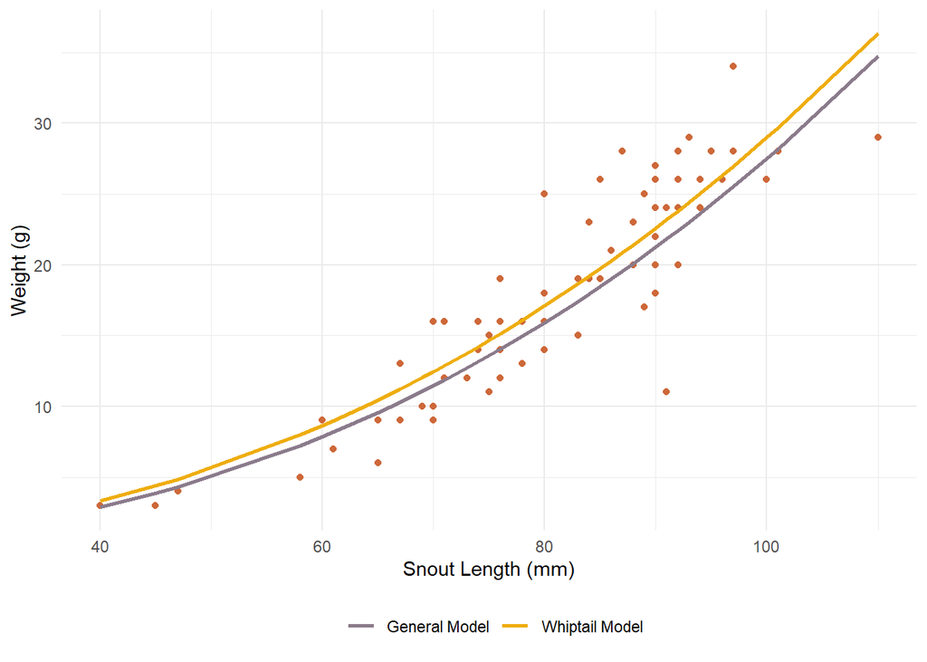

```r
#Plot the NLS for the full data against the NLS for the Whiptail subset, starting by using both models to predict whiptail weight:

# pull only the whiptail predictions from the general model

lizards_complete_whip <- lizards_complete %>%
  filter(spp == "CNTI") %>%
  filter(sex == "Male")

# species-specific prediction

whip_model_predict <- predict(whip_nls)

# bind the species specific prediction to the general prediction

complete_predict <- data.frame(lizards_complete_whip, whip_model_predict)

# From the data frame, we see slight variation in predictions between the two models. Now, we need to calculate the RMSE for both.

rmse_whip <- rmse(whip_nls, complete_predict)

rmse_general <- rmse(lizards_nls, complete_predict)

# Plot the predictions
ggplot(data = complete_predict) +
  geom_point(aes(x = SV_length, y = weight),
             color = "sienna3",
             size = 1.5) +
  geom_line(aes(x = SV_length, y = general_model_predict,
                color = "General Model"), size = 1) +
  geom_line(aes(x = SV_length, y = whip_model_predict,
                color = "Whiptail Model"), size = 1) +
  scale_colour_manual(values =
                      c("General Model" = "thistle4",
                        "Whiptail Model" = "darkgoldenrod2")) +
  theme_minimal() +
  theme(legend.title = element_blank(),
        legend.position = "bottom") +
  labs(x = "Snout Length (mm)",
       y = "Weight (g)")
```

##### **Figure 2:** *This graph shows the actual weight of lizards (red points) compared to predicted weights from both the whiptail-specific model (the yellow line) and the general model (purple line) from* **Figure 1**. *The whiptail-specific model is a better predictor of actual weights* (RMSE =3.35) *compared to the general model* (RMSE = 3.56). *This shows that the species-specific model is the better choice in this analysis.*

The results of the model comparison (using a root-mean squared calculation) show that the model attuned specifically to the male Western Whiptail lizards does a better job at predicting the actual weights of these lizards compared to the generalized model trained on the entire data set.

### **Data Citation**

*Lightfoot, D. and W.G. Whitford. 2020. Lizard pitfall trap data from 11 NPP study locations at the Jornada Basin LTER site, 1989-2006 ver 37. Environmental Data Initiative. https://doi.org/10.6073/pasta/4a6e258fb49c31e222ecbbcfd128967f*